# Prediabetes Burden in Nigeria; A Systematic Review and Meta-analysis

M. A. Bashir<sup>1,*</sup> , A. I. Yahaya<sup>1</sup>, Mukhtar Muhammad<sup>1</sup>, A.H. Yusuf<sup>1</sup>, I.G. Mukhtar<sup>2</sup>

2021-11-11

<sup>1</sup>Department of Anatomy, Bayero University Kano, Kano State, Nigeria  
<sup>2</sup>Department of Physiology, Bayero University Kano, Kano State, Nigeria *Author of Correspondence, Email: musabashir34@gmail.com, GSM: +2347036878467

**Keywords**: Prediabetes, Nigeria, Impaired Glucose Tolerance, Systematic Review, Meta-analysis

# 1 INTRODUCTION

Prediabetes is a borderline glycemic recognized as a toxic cardio-metabolic state similar to what is observed in established diabetes(2). Consequently, many macrovascular and microvascular complications of diabetes exist in the prediabetic state(3). Prediabetes is a heterogenous entity including Impaired Fasting Glucose (IFG), defined as Fasting Blood Sugar (FBS) in the range 5.6 to 6.9mmol/L, Impaired Glucose Tolerance (IGT), defined as 2-hour blood sugar between 7.8 to 11.0mmol/L during glucose tolerance test(OGTT) and raised glycosylated hemoglobin (HbA1c)levels in the range 5.7 to 6.4%(4). **The first coinage of the term ‘impaired glucose tolerance’ was used first in 1979 by a Word Health Organization (WHO) Expert Committee on Diabetes Mellitus and the OGTT range for IGT defined by the committee has not changed since then (5). The term ‘prediabetes’ was popularized by An international expert committee was raised by the American Diabetic Association in 1995 which adopted the IGT defition by WHO but also coined the new condition ‘Impaired Fasting Glucose’ (IFG) defined as fasting venous plasma glucose 5.6mmol/L to 6.9mmol/L(6). The ADA proposed HbA1c values 5.7%-6.4% as a third definition of prediabetes in addition to IFG and IGT. The decision on this HbA1c threshold was based in its capacity to predict, as a composite risk factor, prevalence of diabetes and cardiovascular events that is equivalent to what IFG and IGT predict(7).**

A recent meta-analysis of 59 prospective studies, showed that the pre-diabetic individuals have almost six(6) times risk of developing diabetes than normoglycemic individuals. This risk ranged from as high as eleven (11) times for studies that used the HbA1C or ADA FBS criteria to as low as three (3) times for studies that used IGT criteria(8). Prediabetes not only predisposes to higher risk of progression to diabetes but is by itself an independent risk factor for cardiovascular disease. A meta-analysis of 129 studies comprising of 10 069 955 individuals, found prediabetes to predispose to higher risk of all cause mortality, composite cardiovascular disease, coronary heart disease and stroke. In particular, the WHO FBS criteria of prediabetes was associated with 1.26 relative risk of all cause mortality compared to normoglycemia. The corresponding risk for ADA FBS criteria was 1.03. The corresponding relative risks for coronary heart disease for the two criteria were 1.12 and 1.05 respectively. Interestingly, the meta-analysis reported a lower relative risk of developing stroke, compared to normoglycemia, if ADA FBS criteria was used. The WHO FBS criteria, however, was associated with stroke relative risk of 1.18 compared to normoglycemia(9).

In another recent meta-analysis of 15 prospective studies with median follow-up of 8 years and comprising 9,827,430 individuals, prediabetes was associated with increased incidence of heart failure (RR 1.58, 95% CI 1.04-2.39, for IGT) compared to normoglycemia(10). Prediabetes was also found in another recent meta-analysis to adversely affect outcome in heart failure patients with all-cause mortality HR of 1.29 (95% CI 1.06-1.58)(11).

The International Diabetes Federation(IDF) estimated the prevalence of prediabetes in Nigeria in 2003 to be at 7.3% and projected that, by 2025, the number of individuals with prediabetes in the country will almost double but the prevalence will remain at 7.3% because of increasing population.(12). A more recent regional estimate sets the prevalence of prediabetes(defined as IGT) of the African region at 10.1% (CI = 5.6% to 22.7%) translating to 45.3 million individuals. It is of note that neither the 2003 nor the 2019 IDF reports included data from Nigeria in the estimation of prediabetes prevalence (12,13). To the best of our knowledge, this is the first systematic review and meta-analysis of prediabetes prevalence in Nigeria since the 2003 publication by the IDF.

# 2 METHODOLOGY

## 2.1 Study Area

Nigeria is a western African nation with an area of 923,769 sq km, home to more than 250 ethnic groups (14). It has 36 states and a capital divided into 6 geo-political zones or regions. The estimated population in 2021 is 211.4 million. 43.4% of the population are under the age of 14 years. 53.9% of the population are between the ages of 15 and 64 years. Only 2.8% of the population are above the age of 65 years.(1). Figure 2.1 shows the map of the geopolitical zones of the country.

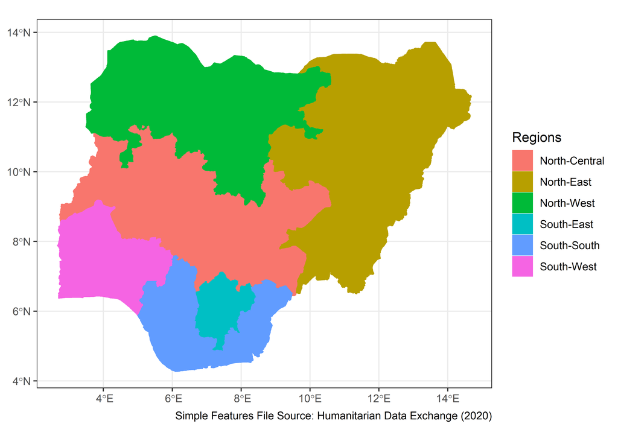

Figure 2.1: Geo-Political Zones in Nigeria

## 2.2 Inclusion and Exclusion Criteria

We included community-based studies conducted in adult population (greater than 18 years of age) of Nigeria. Studies selected defined prediabetes using both ADA and WHO criteria and used HbA1C, FBS and IGT definitions. We excluded studies conducted in individuals less than 18 years of age, studies on pregnant women and all hospital-based studies.

## 2.3 Studies Search Strategies

Online databases used were Google Scholar, PubMed and Scopus. Search words and phrases used were: ‘impaired fasting glucose,’ impaired fasting sugar’, ‘impaired glucose tolerance,’ ‘prediabetes’ and “borderline glycemic state” .Search was repeated for each word or phrase with the name ‘Nigeria.’ Search was conducted between March 2021 to November 2021. Screening of the abstracts and titles of the articles was done independently by two reviewers (MAB and IGM) and studies selection and exclusion done based on the predefined criteria. Thereafter, screening of the full-text articles was done independently by the same researches to select the studies to be included in qualitative and quantitative analyses.

## 2.4 Qualitative Analysis of the Included Studies

The methodological quality of the included studies was assessed using a modification of the Joanna Briggs Institute (JBI) Critical Appraisal Checklist for Studies Reporting Prevalence Data(15). The item’s original 9 questions were reduced to six (6) with questions one (1) and two (2) given a score of two (2) and the remaining four (4) question each given a score of one (1) for a ‘yes’ and zero (0) for a ‘no.’ The total maximum score is eight(8). A study was judged as good quality if it scored minimum of six (6) and of poor quality if it scores less than six (6). Assessment was done independently by two reviewers (AHY and MM) with disagreements sorted by AIH. Table 2.1 shows the modified tool used in critical appraisal of the included studies. The minimum sample size for scoring a study as a ‘yes’ was one hundred and two (102) calculated using Epitools(16) online calculator assuming an estimated prevalence of 7.1% based on a recent meta-analysis of studies conducted in neighboring Cameroon(17). Reliability and Validity of methods was assessed based on whether the studies used glucose oxidase methods or Point of Care Glucometers for measurement of blood glucose levels. Only studies judged as having high methodological quality were included in the quantitative analysis.

Table 2.1: Critical Appraisal Checklist

| S.N | Question | Yes | No |
| --- | --- | --- | --- |
| 1 | Was the sample frame appropriate to address the target population? | 2 | 0 |
| 2 | Were study participants sampled in an appropriate way? | 2 | 0 |
| 3 | Was the sample size adequate? | 1 | 0 |
| 4 | Were the study subjects and the setting described in detail? | 1 | 0 |
| 5 | Were valid methods used for the identification of the condition? | 1 | 0 |
| 6 | Was the condition measured in a standard, reliable way for all participants? | 1 | 0 |
|  | Total Score |  |  |

## 2.5 Data Extraction and Quantitative Analysis

Data extraction was independently done by two reviewers (MAB and IGM). Extracted information from the studies included prevalence of prediabetes, sample size, settlement (urban/rural), state and region of the study, study year, mean age and sex composition of the study participants. Data was entered into Excel and then imported into R statistical environment for statistical computing, version 4.1.0.1(18). Metafor Package(19) was used to fit Multi-level Random Effects Model for pooling prevalence rates and Multi-level Mixed Effects Model for meta-regression using inverse variance method with correction of pooled estimate and its variance using Sidik-Jonkman’s estimator for between study heterogeneity(20). The 3 levels of the multi-level models are as follows:

1. Level 1: variance explained by sampling errors of the included studies
2. Level 2: between study heterogeneity
3. Level 3: heterogeneity between clusters of studies with clusters defined by the methods of defining prediabetes i.e. IGT, HbA1c, FBS under ADA criteria and FBS under WHO Criteria.

Because the ADA and IGT criteria for prediabetes are not mutually exclusive (both defined IGT the same way), comparison of the pooled prevalence rates under the two criteria could not be done through meta-regression or sub-group analyses. Consequently, the prevalence rates under the two criteria were pooled separately.

The analysis of heterogeneity was done both through a meta-regression using characteristics of the included studies as predictors. Comparison of between study heterogeneity measures in the model with and model without moderators was done. Additionally, distribution of heterogeneity between the three levels of the model was calculated using the formula developed by Cheung (21) and implemented in dmetar R package(22).  
Finally, Prediction Intervals were reported to overcome the difficulties in interpreting both tau<sup>2</sup> and I<sup>2</sup> as measures of between study heterogeneity(23)

Funnel plot was used to visually inspect for possible publication bias where studies reporting small prevalence were not published and thus not included in the meta-analysis. Formal regression test develooped by Egger and colleagues(24) was employed for testing funnel plot asymmetry.

# 3 RESULTS

## 3.1 Search Results

10934 studies were retrieved from the databases, with titles and abstracts of 8269 studies screened after duplicates were removed. Full text of 96 studies were assessed for eligibility with 53 studies included in qualitative analysis. (Figure 3.1)

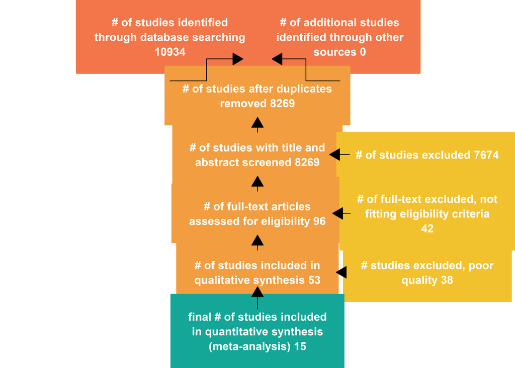

Figure 3.1: Results of the Search

[output not shown]

## 3.2 Methodological features and the Critical Appraisal of the Included Studies

53 studies were selected and included in the qualitative analysis of methodological features. The quality appraisal of the included studies is shown in the supplementary material.

## 3.3 Characteristics of the Studies Included in the Quantitative Analysis

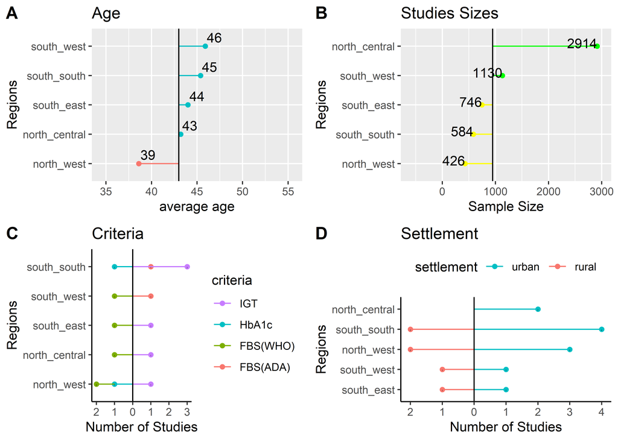

Figure 3.2: Characteristics of the Included Studies

## 3.4 Fitting the Meta Analytic Model

Random Effects Model was fitted using inverse variance method with correction of pooled estimate and its variance using Sidik-Jonkman’s estimator for between study heterogeneity. Prevalences are transformed using arcsine transformation. Prevalences under ADA and WHO criteria were pooled separately. Figure 3.3 shows the forest plot of the model.

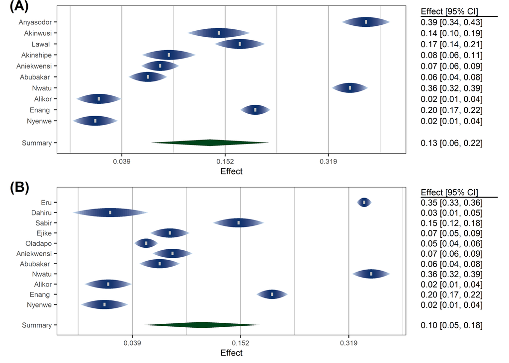

Figure 3.3: forest plot

The overall pooled prevalence of prediabetes in Nigeria is 13.2% (95% CI: 5.6%-23.2%) using the ADA criteria and 10.4% (95% CI: 4.3%-18.9%) using the WHO criteria. According to the latest data by the United Nations(1), this translates to estimated 15.8 million and 12.5 adult prediabetic individuals in Nigeria using the ADA and WHO criteria respectively. The *P* values for the random meta analytic model is <0.001 for the models under the two criteria(ADA and WHO). The estimated total between studies heterogeneity not explained by sampling error (I<sup>2</sup>) under both criteria is about 99.2%. Test for Heterogenity is significant with p-value<0.001 indicating substantial heterogeneity between the included studies. Prediction Intervals for the models under ADA and WHO criteria are 0%-51.8% and 0%-46% respectively.

## 3.5 Analysis of Between Study Heterogeneity

For the model under ADA criteria, a multilevel meta-regression model was fitted using geo-political region as a moderator. Figure 3.4 shows the distribution of the heterogeneity. Most of the substantial heterogenity (almost 60% of it) is attributable to the use of different methods of defining prediabetes by the included studies (IGT, HbA1c or FBS). The between study heterogeneity (Level 2 of the model) accounts for about 40% of the heterogeneity.

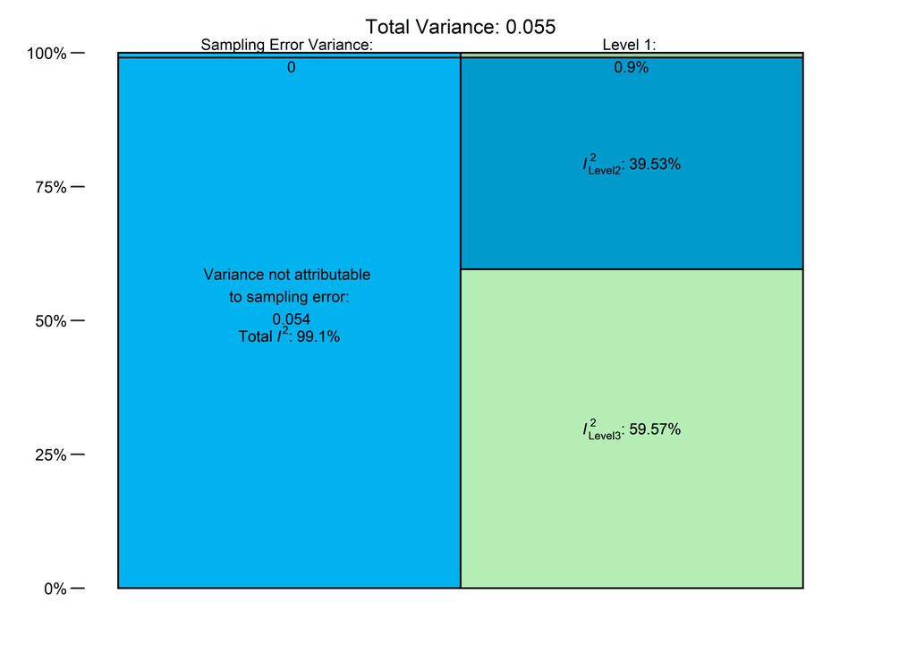

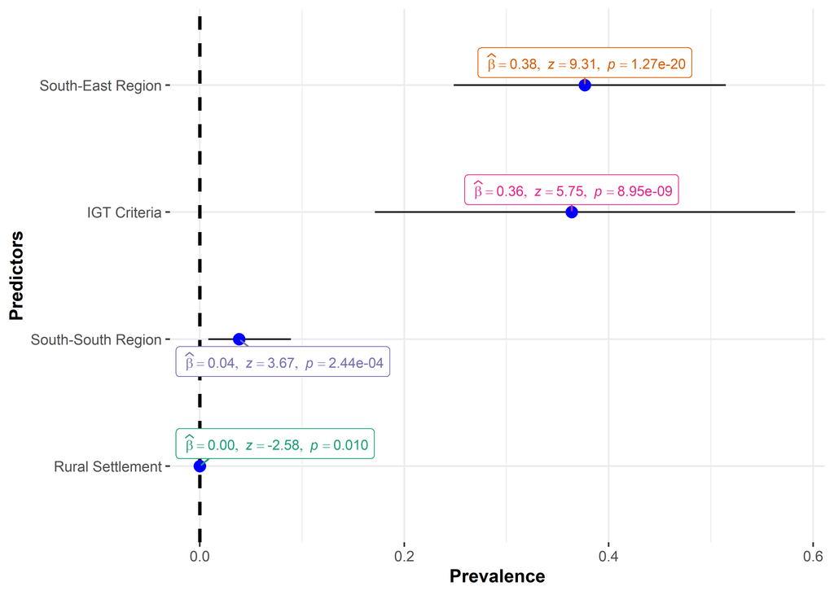

Figure 3.5: WHO Criteria Meta-regression

## 3.6 Analysis of Publication Bias

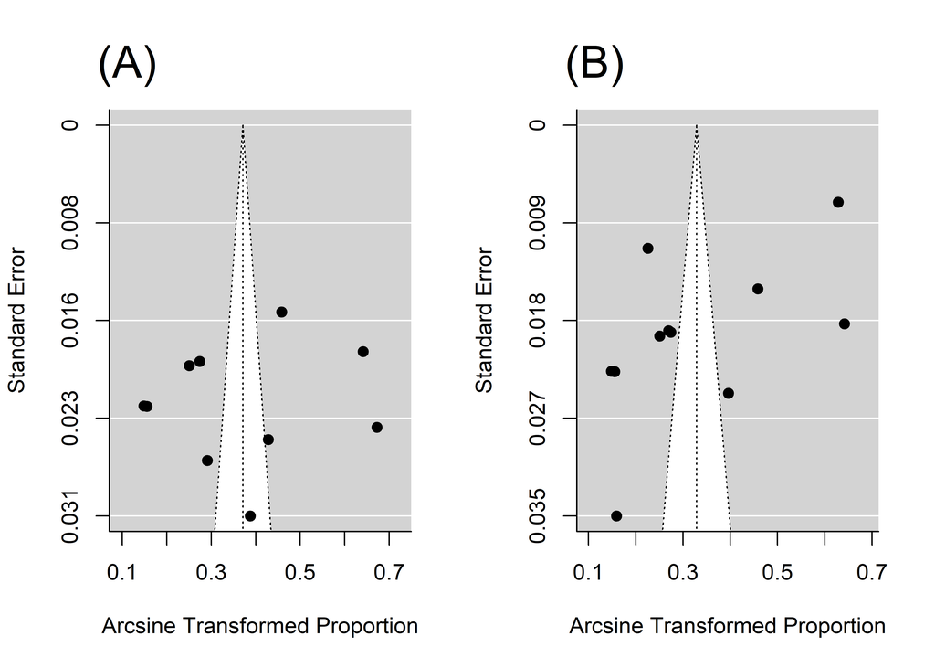

Figure 3.6: Funnel Plots of the Models

Figure 3.6 shows the funnel plot of the model under ADA (plot (A)) and WHO (plot(B)) criteria respectively. There was no obvious asymmetry in the plots. Formal test for plot asymmetery (regression test) was conducted and it was not statistically significant (*P* value is 0.816 and 0.052 for the model under ADA and WHO criteria respectively), confirming the visual assessment of the funnel plot.

## 3.7 Gender-Specific Prevalence of Prediabetes

The prevalence rates for females and males are similar at 12.1% (95% CI: 5%-21%) and 10.4% (95% CI: 4%-20%) under WHO and ADA criteria respectively.

## 3.8 Prevalence of Prediabetes between Urban and Rural Settlements in Nigeria